# Neural Networks for Function Approximation

∿Numerical Tours

# Neural Networks for Function Approximation

## Run this tour

Run the cells in order with a Python 3 kernel. The first cell locates the companion data and toolbox and installs missing dependencies when needed. All worked examples include their implementation directly in this notebook. Random seeds make comparisons reproducible; you can change them to explore other samples.

```python
# Locate the companion toolbox locally, or fetch it for a standalone/Colab copy.
from pathlib import Path
import importlib.util
import os
import subprocess
import sys

working = Path.cwd()
candidates = [working, working / "python", working.parent / "python"]
python_dir = next((p for p in candidates if (p / "nt_toolbox").is_dir()), None)
if python_dir is None:
    checkout = working / "numerical-tours-support"
    if not checkout.exists():
        subprocess.run(
            [
                "git",
                "clone",
                "--depth",
                "1",
                "--branch",
                "master",
                "https://github.com/gpeyre/numerical-tours.git",
                str(checkout),
            ],
            check=True,
        )
    python_dir = checkout / "python"
os.chdir(python_dir)
if str(python_dir) not in sys.path:
    sys.path.insert(0, str(python_dir))
requirements = python_dir / "requirements.txt"
if any(
    importlib.util.find_spec(name) is None
    for name in [
        "numpy",
        "scipy",
        "matplotlib",
        "skimage",
        "sklearn",
        "pywt",
        "ipywidgets",
        "cvxpy",
        "skfmm",
        "autograd",
        "progressbar",
        "celer",
    ]
):
    subprocess.run(
        [sys.executable, "-m", "pip", "install", "-r", str(requirements)], check=True
    )
if (
    importlib.util.find_spec("torch") is None
    or importlib.util.find_spec("torchvision") is None
):
    subprocess.run(
        [
            sys.executable,
            "-m",
            "pip",
            "install",
            "-r",
            str(python_dir / "requirements-torch.txt"),
        ],
        check=True,
    )

import numpy as np
import matplotlib.pyplot as plt

np.random.seed(0)
plt.rcParams.update(
    {
        "figure.figsize": (8, 4),
        "figure.dpi": 100,
        "axes.spines.top": False,
        "axes.spines.right": False,
        "font.size": 11,
        "image.cmap": "gray",
    }
)
%matplotlib inline
```

## Approximation using Multi-layers Perceptrons

This code benchmark the approximation of functions using a Multi-Layer Perceptron (MLP) with 2 layers. A MLP with $q$ neurons is defined as $$ \forall x \in \mathbb{R}^d, \quad f_q(x) \triangleq \sum_{k=1}^q c_k \phi( \langle x,a_k \rangle + b_k ) $$ where the parameters are $(a_k,b_k,c_k) \in \mathbb{R}^{d} \times \mathbb{R} \times \mathbb{R}$, so that the total number of parameters is $q (d+2)$. Here $\phi : \mathbb{R} \to \mathbb{R}$ is a sigmoid function with bounded range (assumed to be $[0,1]$).

The theorem of Barron ensures that for a class of smooth function with $$ \|f\|_B \triangleq \int_{\mathbb{R}^d} \|\omega\| |\hat f(\omega)| \text{d} \omega < +\infty $$ and a probability distribution $\mu$ supported on a ball of radius $R$, there exists a neural MLP $f_n$ with $n$ neurons such that

$$ \int (f(x)-f_q(x))^2 \text{d} \mu(x) = O(\|f\|_B R / \sqrt{q}). $$

The goal of this tour is to illustrate this theorem.

```python
import numpy as np
import matplotlib.pyplot as plt
import torch

torch.manual_seed(0)
torch.set_num_threads(1)
import torch.nn as nn
import torch.optim as optim
```

```python
device = torch.device("cuda" if torch.cuda.is_available() else "cpu")
print(device)
```

```
cpu
```

## Approximation using gradient descent

Create synthetic data in dimension $d$.

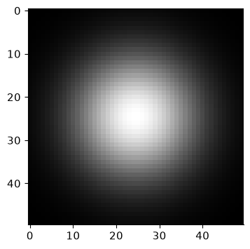

```python
d = 1
d = 3
d = 2
if d == 1:
    n = 256  # #samples
    x = np.linspace(-1, 1, n)
    y = np.sin(6 * np.pi * np.abs(x) ** 1.5) + np.abs(x) ** 2
    x = x[:, None]
    y = y[:, None]
    plt.clf()
    plt.plot(x, y)
if d == 2:
    n0 = 50
    n = n0**2
    t = np.linspace(-1, 1, n0)
    s = 0.4  # width of the Gaussian
    y = np.exp(-(t[:, None] ** 2 + t[None, :] ** 2) / (2 * s**2))
    y = y.flatten()
    [u, v] = np.meshgrid(t, t)
    x = np.concatenate([u.flatten()[:, None], v.flatten()[:, None]], axis=1)
    plt.imshow(np.reshape(y, [n0, n0]))
if d > 2:
    # random point on a cube
    n = 1000
    x = 2 * np.random.rand(n, d) - 1
    s = 0.4  # width of the Gaussian
    y = np.exp(-np.sum(x**2, axis=1) / (2 * s**2))
    y = y.flatten()
    plt.plot(np.sum(x, axis=1), y, ".")
```

```python
X = torch.Tensor(x).to(device)
Y = torch.Tensor(y[:, None]).to(device)
```

Define a MLP with $q$ hidden neurons.

```python
def create_mlp(q):
    model = nn.Sequential(
        nn.Linear(d, q),
        nn.Tanh(),
        # nn.Sigmoid(),
        # nn.ReLU(),
        nn.Linear(q, 1),
    )
    if torch.cuda.is_available():
        model.cuda()
    return model
```

Initialize the weights.

```python
def my_init(m):
    nn.init.normal_(m[0].bias, 0, 1)
    nn.init.normal_(m[0].weight, 0, 1)
    nn.init.normal_(m[2].bias, 0, 0.001)  # set it to 0 for the global bias
    nn.init.normal_(m[2].weight, 0.0001)
```

```python
q = 10  # neurons
model = create_mlp(q)
my_init(model)
```

Define the $\ell^2$ loss function.

```python
loss_func = torch.nn.MSELoss()
loss = loss_func(model(X), Y)
print(loss.item())
```

```
21.410419464111328
```

implementing "by hand" the gradient descent.

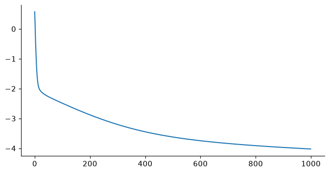

```python
my_init(model)
tau = 0.01
niter = 1000
L = np.zeros((niter, 1))
for i in range(niter):
    loss = loss_func(model(X), Y)
    L[i] = loss.item()
    model.zero_grad()
    loss.backward()
    with torch.no_grad():
        for theta in model.parameters():
            theta -= tau * theta.grad
plt.plot(np.log(L));
```

Same using Pytorch.

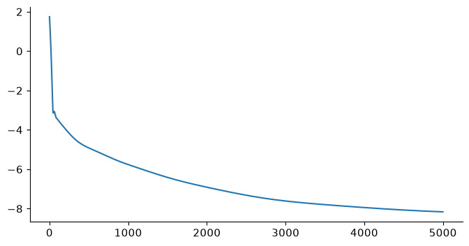

```python
my_init(model)
optimizer = torch.optim.SGD(model.parameters(), lr=0.01)
optimizer = torch.optim.Adam(model.parameters(), lr=0.01)
model.train()
niter = 5000
L = []
for it in range(niter):
    loss = loss_func(model(X), Y)
    model.zero_grad()  # reset the gradient
    loss.backward()
    L.append(loss.item())
    optimizer.step()
plt.plot(np.log(L));
```

Quasi-Newton.

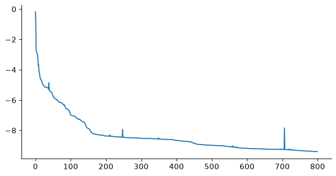

```python
my_init(model)
optimizer = optim.LBFGS(model.parameters())
niter = 40
L = []
for it in range(niter):

    def closure():
        optimizer.zero_grad()  # reset the gradient
        loss = loss_func(model(X), Y)
        model.zero_grad()
        loss.backward()
        L.append(loss.item())
        return loss

    optimizer.step(closure)
plt.plot(np.log(L));
```

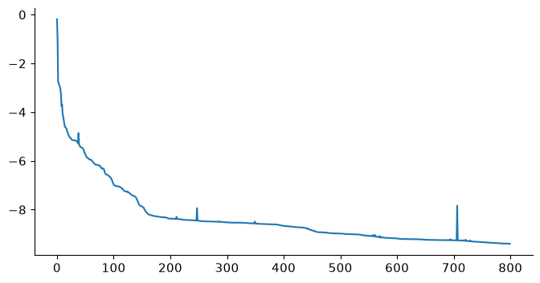

```python
plt.plot(np.log(L));
```

Display the repartition of the weights.

```
Output bias:[1.2186292]
```

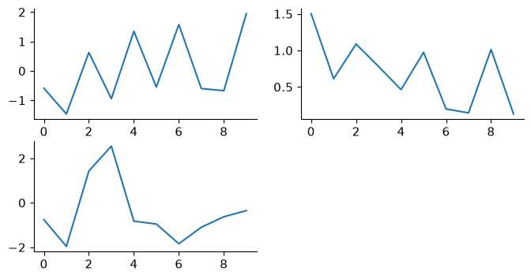

```python
def torch2np(x):
    return x.detach().cpu().numpy()


plt.subplot(2, 2, 1)
plt.plot(torch2np(model[0].bias))
plt.subplot(2, 2, 2)
plt.plot(np.std(torch2np(model[0].weight), axis=1))
plt.subplot(2, 2, 3)
plt.plot(torch2np(model[2].weight).flatten())
print("Output bias:" + str(torch2np(model[2].bias.data)))
```

Display the fitted function.

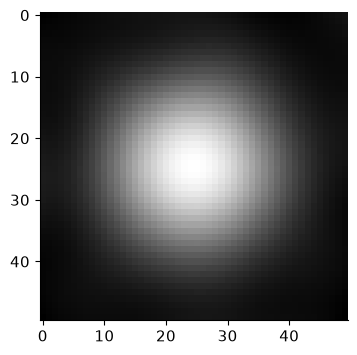

```python
y1 = model(X).detach().cpu().numpy()
if d == 1:
    plt.plot(x, y, "b")
    plt.plot(x, y1, "r")
if d == 2:
    y1 = np.reshape(y1, [n0, n0])
    plt.imshow(y1)
if d > 2:
    plt.plot(np.sum(x, axis=1), y, "b.")
    plt.plot(np.sum(x, axis=1), y1, "r.")
```

## Geedy neuron-by-neuron training

In order to illustrate Barron's theorem, we train the network in a greedy fashion, neuron per neuron.

```python
import time
import progressbar

R = Y  # residual to fit
qmax = 500  # maximum # neurons
niter = 500  # for the optimizer

L = [loss_func(R * 0, R).item()]  # bug, model(X) doit model=0
for iq in progressbar.progressbar(range(qmax)):
    # create a MLP with a single neuron
    model = create_mlp(1)
    my_init(model)
    # be sure to start from 0
    model[2].bias.data = 0 * model[2].bias.data
    model[2].weight.data = 0 * model[2].weight.data

    # optimizer = optim.LBFGS(model.parameters());
    # optimizer = torch.optim.SGD(model.parameters(), lr = 0.01)
    optimizer = torch.optim.Adam(model.parameters(), lr=0.01)
    model.train()

    l = []
    for it in range(niter):
        if 0:

            def closure():
                optimizer.zero_grad()  # reset the gradient
                loss = loss_func(model(X), R)
                model.zero_grad()
                loss.backward()
                l.append(loss.item())
                return loss

            optimizer.step(closure)
        else:
            loss = loss_func(model(X), R)
            model.zero_grad()  # reset the gradient
            loss.backward()
            l.append(loss.item())
            optimizer.step()

    # update residual
    L.append(loss_func(model(X), R).item())  # loss.item())
    R = R - model(X).detach()
```

[output not shown]

[output not shown]

[output not shown]

[output not shown]

[output not shown]

[output not shown]

[output not shown]

[output not shown]

[output not shown]

[output not shown]

[output not shown]

[output not shown]

[output not shown]

[output not shown]

[output not shown]

[output not shown]

[output not shown]

[output not shown]

[output not shown]

[output not shown]

[output not shown]

[output not shown]

[output not shown]

[output not shown]

[output not shown]

[output not shown]

[output not shown]

[output not shown]

[output not shown]

[output not shown]

[output not shown]

[output not shown]

[output not shown]

[output not shown]

[output not shown]

[output not shown]

[output not shown]

[output not shown]

[output not shown]

[output not shown]

[output not shown]

[output not shown]

[output not shown]

[output not shown]

[output not shown]

[output not shown]

[output not shown]

[output not shown]

[output not shown]

[output not shown]

[output not shown]

[output not shown]

[output not shown]

[output not shown]

[output not shown]

[output not shown]

[output not shown]

[output not shown]

[output not shown]

[output not shown]

[output not shown]

[output not shown]

[output not shown]

[output not shown]

[output not shown]

[output not shown]

[output not shown]

[output not shown]

[output not shown]

[output not shown]

[output not shown]

[output not shown]

[output not shown]

[output not shown]

[output not shown]

[output not shown]

[output not shown]

[output not shown]

[output not shown]

[output not shown]

Display the evolution of the loss in log-domain, and compare with the theoretical bound in $O(1/\sqrt{q})$.

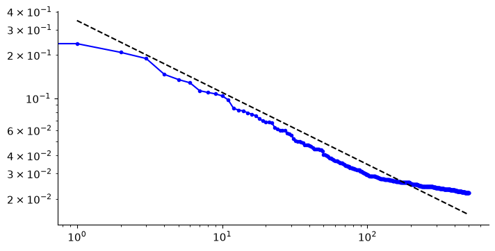

```python
qlist = np.arange(qmax + 1)
plt.loglog(qlist, np.sqrt(L), "b.-")
plt.loglog(qlist[1:], np.sqrt(L[0]) / np.sqrt(qlist[1:]), "k--");
```

## References and further reading

- Ian Goodfellow, Yoshua Bengio, and Aaron Courville. [Deep Learning](https://www.deeplearningbook.org/). 2016, MIT Press. Neural networks, automatic differentiation, and optimization.
- David E. Rumelhart, Geoffrey E. Hinton, and Ronald J. Williams. [Learning Representations by Back-Propagating Errors](https://doi.org/10.1038/323533a0). 1986, Nature 323, 533–536. The chain-rule computation underlying multilayer network training.
- Diederik P. Kingma and Jimmy Ba. [Adam: A Method for Stochastic Optimization](https://arxiv.org/abs/1412.6980). 2015, ICLR. Adaptive stochastic gradient updates for neural network training.
- Léon Bottou, Frank E. Curtis, and Jorge Nocedal. [Optimization Methods for Large-Scale Machine Learning](https://arxiv.org/abs/1606.04838). 2018, SIAM Review 60(2), 223–311. Stochastic gradients, variance reduction, and practical convergence.
- Trevor Hastie, Robert Tibshirani, and Jerome Friedman. [The Elements of Statistical Learning](https://hastie.su.domains/ElemStatLearn/). 2009, 2nd ed., Springer. Regression, classification, regularization, and model assessment.